# Demografi: opgaver 6

Johan Sebastian Ohlendorff

# Setup

Forestil dig følgende situation: Der skal bygges nye boliger for flygtningefamilier. Flygtninge er for det meste forældre mellem 25 og 60 år med børn. Spørgsmålet er, om placeringen af boligerne enten skal placeres i Bornholm eller Hillerød kommune. Din opgave er at belyse fordele og ulemper ved de to beliggenheder med demografiske data.

# Opgave 1

Se på aldersfordelingerne i Bornholm og Hillerød kommune i 2010 og 2023.

Genbrug R-koder fra opgaverne fra uge 3, hvor du indsætter “Bornholm” og “Hillerød” i stedet for “Region Hovedstaden” og “Region Sjælland”.

# Kode

```r
# R-koder der genererer alderspyramiden for 2 regioner den 1. juli 2010 og 1. juli 2023
folk <- hent_data("FOLK1a","alder"=0:125,"køn"=1:2,tid=c("2010K3","2023K3"),Område = c("Bornholm","Hillerød"))
# Fjern aldere, der har folketal 0
folk <- subset(folk,alder<106)
# Mænd skal vises på venstresiden, derfor bliver INDHOLD negativt
folk_m <- subset(folk,KØN=="Mænd") %>% mutate(INDHOLD=-INDHOLD)
# For kvinder på højresiden er INDHOLD positivt
folk_k <- subset(folk,KØN=="Kvinder")
# Grafik
g <- ggplot(folk, aes(x = alder, y = INDHOLD, fill = KØN)) +
  geom_bar(data=folk_m, stat = "identity") +
  geom_bar(data=folk_k, stat = "identity") +
  coord_flip() + theme_economist() +
  ylab("Folketal N(t)")+xlab("Alder (år)") +
  theme(legend.title=element_blank())
g <- g+ggtitle("Alderspyramide 1. juli")
g <- g+theme(axis.title.y=element_text(margin=margin(t=0,r=20,b=0,l=0)))
g <- g+theme(axis.title.x=element_text(margin=margin(t=20,r=0,b=0,l=0)))
g + facet_grid(OMRÅDE~TID)
```

# Output

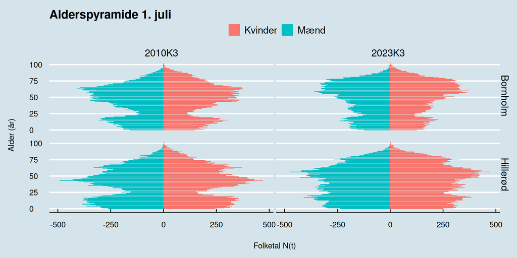

# Opgave 2

# Kode

```r
beregn_middellevetid(tid = c(2010,2020),
                     breaks = c(0:95,Inf),
                     område = c("Bornholm","Hillerød"),
                     køn = c("kvinder","mænd"))
```

# Output

| KØN | TID | OMRÅDE | e |
| --- | --- | --- | --- |
| Kvinder | 2010 | Bornholm | 81,7 |
| Kvinder | 2010 | Hillerød | 80,8 |
| Kvinder | 2020 | Bornholm | 82,4 |
| Kvinder | 2020 | Hillerød | 84,5 |
| Mænd | 2010 | Bornholm | 75,7 |
| Mænd | 2010 | Hillerød | 78,3 |
| Mænd | 2020 | Bornholm | 77,2 |
| Mænd | 2020 | Hillerød | 78,7 |

# Opgave 3

Beregn fødselsrater i kommunerne Bornholm og Hillerød i 2010 og 2023.

```r
# 2023
F <- hent_data("FODIE",område = c("Bornholm","Hillerød"),
               tid = c(2010,2023))
F <- rename(F,Fødsler = INDHOLD)
R <- hent_data("FOLK1a",område = c("Bornholm","Hillerød"),
               tid = c("2010K3","2023K3"))
R <- mutate(R,TID = as.numeric(sub("K3","",TID)),Risikotid = INDHOLD)
x <- left_join(F,R,by = c("OMRÅDE","TID"))
x <- mutate(x,Frate = 1000* Fødsler/Risikotid)
x
```

# Output

| TID | OMRÅDE | Fødsler | INDHOLD | Risikotid | Frate |
| --- | --- | --- | --- | --- | --- |
| 2010 | Bornholm | 306 | 42.066 | 42.066 | 7,3 |
| 2023 | Bornholm | 256 | 39.601 | 39.601 | 6,5 |
| 2010 | Hillerød | 476 | 47.683 | 47.683 | 10,0 |
| 2023 | Hillerød | 493 | 54.191 | 54.191 | 9,1 |

# Opgave 4

Skriv en sammenhængende tekst hvor du rapporter forskelle og udvikling i aldersfordelingerne (beskriv alderspyramiderne), mortalitet (rapporter middellevetid) og fertilitet (rapporter fødselsrater) i de to kommuner. Med udgangspunkt i disse tal, diskuter fordele og ulemper med de to beliggenheder for placeringen af flygtningefamilier med hensyn til at finde arbejde til de voksne og plads i vuggestuer og skoler til børnene.

# Løsning

# Diskussion

- At fødselsraten er lav kan betyde, at der er flere ledige pladser i vuggestuer og børnehaver, hvilket er til fordel for flygtninge med børn i disse aldersgrupper. Færre børn $\Rightarrow$ flere ledige pladser på skolerne. Omvendt er der nok ikke så mange arbejdsmuligheder som i Storkøbenhavn.
- Se skabelonbesvarelse på Absalon.